# OpenWAR

Our goal is to build a fully open-source implementation of Wins Above Replacement (WAR).

### Data Acquisition

We have developed an R package to compute our implementation of WAR. The first step in that process is to get meaningful play-by-play data. We have written parsers that will download and extract data from the Major League Baseball Advanced Media (MLBAM) GameDay server. This data is updated live, and available to the public. Thus, although this data is not “free as in freedom”, it is “free as in beer.”

Using our **openWAR** package, a single game's worth of play-by-play data can be retrieved from the GameDay servers and processed into a data frame. The R class **gameday** contains an object that includes the relevant URLs and XML files, as well as the processed data. The XML files and processed data are cached locally for faster retrieval. Note that since the MLBAM data is not transferrable, all data must be downloaded by the user at least once.

```r
require(openWAR)
gd = gameday()
# Equivalently
data(MetsBraves)
```

#### Single Game data

The default game was played on August 12th, 2012 between the New York Mets and the Atlanta Braves.

```r
gd$gameId
```

```
## [1] "gid_2012_08_12_atlmlb_nynmlb_1"
```

The directory on the GameDay server that contains that actual XML files is located here.

```r
gd$base
```

```
## [1] "http://gd2.mlb.com/components/game/mlb/year_2012/month_08/day_12/"
```

```r
summary(gd)
```

```
##
## Summarizing downloaded data for gid_2012_08_12_atlmlb_nynmlb_1
## ... 121 beat 144 by a score of 6 - 5 in 9 innings
## ...there were 75 plate appearances in the game
```

Our primary interest will be in analyzing the play-by-play data that we have processed for this game. This data contains a complete record of what happened in the game. For example, this game started with Michael Bourn leading off with a double. After a walk to Martin Prado and a strikeout of Jason Heyward, Chipper Jones grounded into an inning-ending 5-4-3 double play.

```r
head(gd$ds)
```

```
##    pitcherId batterId field_teamId ab_num inning   half balls strikes
## 7     477003   456422          121      1      1    top     0       1
## 8     477003   445988          121      2      1    top     4       0
## 9     477003   518792          121      3      1    top     1       3
## 10    477003   116706          121      4      1    top     1       2
## 1     282656   514913          144      5      1 bottom     2       2
## 2     282656   488689          144      6      1 bottom     1       1
##    endOuts            event actionId
## 7        0           Double       NA
## 8        0             Walk       NA
## 9        1        Strikeout       NA
## 10       3 Grounded Into DP       NA
## 1        1           Flyout       NA
## 2        1           Single       NA
##                                                                                                                                                      description
```

[output cut: 76 more lines]

#### Many games

More often, we'll be interested in investigated data from many games. The function **getData()** will load (or download) data over any time interval in which you are interested. Let's figure out how many home runs were hit on May 14th, 2013.

```r
ds = getData(start = "2013-05-14")
```

```
##
## Retrieving data from 2013-05-14 ...
## ...found 15 games
```

```r
subset(ds, event == "Home Run", select = c("gameId", "batterId", "description"))
```

```
##                              gameId batterId
## 710  gid_2013_05_14_bosmlb_tbamlb_1   120074
## 102  gid_2013_05_14_chamlb_minmlb_1   276055
## 113  gid_2013_05_14_chamlb_minmlb_1   493364
## 216  gid_2013_05_14_clemlb_phimlb_1   435623
## 454  gid_2013_05_14_clemlb_phimlb_1   502126
## 165  gid_2013_05_14_colmlb_chnmlb_1   458913
## 225  gid_2013_05_14_colmlb_chnmlb_1   471865
## 365  gid_2013_05_14_colmlb_chnmlb_1   446381
## 77   gid_2013_05_14_colmlb_chnmlb_1   471865
## 526  gid_2013_05_14_houmlb_detmlb_1   408234
## 228  gid_2013_05_14_kcamlb_anamlb_1   405395
## 257  gid_2013_05_14_kcamlb_anamlb_1   435062
## 487  gid_2013_05_14_kcamlb_anamlb_1   456714
## 428  gid_2013_05_14_kcamlb_anamlb_1   285078
```

[output cut: 43 more lines]

#### Visualizing the data

The best part about the MLBAM data is that it contains an \( (x,y) \)-coordinate indicated the location of each batted ball hit into play. We can visualize this.

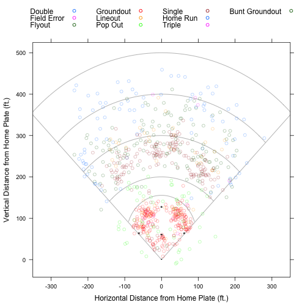

```r
bbplot(data = ds)
```

### Modeling

In order to compute **openWAR**, we need to model several quantities. The first thing we need to understand is the relative value of each “state” of a half-inning. Since there are three bases, each of which can be either occupied or unoccupied, and there are three possible numbers of outs, each plate appearance begins with the half-inning in one of 25 possible states (the 24 states, plus one last state for three outs). We would like to assign a value to each one of these states that indicates the expected number of runs that will be scored in the remainder of that half-inning. We have precomputed the states and the number of **futureRuns** associated with each play.

Thus, we want to fit the model \[ futureRuns \sim baseCode + outs + baseCode \cdot outs, \] where \( baseCode \) is a description of the configuration of the baserunners, and \( outs \) is the number of outs in the half-inning.

For example, consider the bottom of the 1st inning of our game:

```r
subset(gd$ds, inning == 1 & half == "bottom", select = c("runsFuture", "runsOnPlay",
    "startCode", "startOuts", "description"))
```

```
##   runsFuture runsOnPlay startCode startOuts
## 1          2          0         0         0
## 2          2          0         0         1
## 3          2          1         1         1
## 4          1          1         4         1
## 5          0          0         1         1
## 6          0          0         1         2
##                                                                                                                                                                            description
## 1                                                                                                                            Ruben Tejada flies out to center fielder Michael Bourn.
## 2                                                                                                                Mike Baxter singles on a line drive to right fielder Jason Heyward.
## 3 David Wright doubles (34) on a line drive to right fielder Jason Heyward.   Mike Baxter scores.  David Wright advances to 3rd, on a throwing error by right fielder Jason Heyward.
## 4                                                                                           Ike Davis singles on a line drive to right fielder Jason Heyward.   David Wright scores.
## 5                                                                                                                              Daniel Murphy lines out to left fielder Martin Prado.
## 6                                                                                                                                       Jordany Valdespin strikes out on a foul tip.
```

The Mets scored two runs in the inning, and thus, when Ruben Tejada opened the inning, there were no runners on base, no outs, but two \( futureRuns \) were associated with this play. After Tejada flew out, there was one out, but still no one on base and two \( futureRuns \). After Mike Baxter singles, David Wright came to the plate with a runner on first (bc_before = 1), one out, and two \( futureRuns \). His double scored one run, so Ike Davis followed with a runner on third, one out, and now only one \( futureRuns \). By the time Daniel Murphy bats, there are no further \( futureRuns \) in the inning.

Every inning begins with no one on and no one out. In this example, two runs scored in the inning. By averaging over all innings, we create an estimate of the expected \( futureRuns \) for the state \( (0,0) \). But we can just as easily do the same for all states.

#### Building a model for expected runs

The simplest way to build a model for \( futureRuns \) is to take the average over all observations. To do this, we'll need more data.

```r
ds = # Will take a loooong time -- the first time
# ds = getWeeklyData("2013-04-01")
# ds = getWeeklyData("2013-04-08")
# ds = getWeeklyData("2013-04-15")
# ds = getWeeklyData("2013-04-22")
# ds = getData("2013-03-31")
# 2013 first half
# ds = getData("2013-03-31", end="2013-07-14")

# ds = getMonthlyData(2013, 6)
# MLBAM2013 = ds
# save(MLBAM2013, file="data/MLBAM2013.rda")
data(MLBAM2013)
ds = MLBAM2013
```

First, some basic accounting to make sure that our data is accurate. Compare these with [Baseball-reference.com](http://www.baseball-reference.com/leagues/MLB/2013-standard-batting.shtml)

```r
sort(tally(~event, data = ds), decreasing = TRUE)
```

```
##
##                    Total                Strikeout                Groundout
##                   107774                    21161                    20678
##                   Single                   Flyout                     Walk
##                    16417                    13773                     7837
##                  Pop Out                  Lineout                   Double
##                     5144                     5112                     4838
##                 Home Run                 Forceout         Grounded Into DP
##                     2804                     2276                     2164
##             Hit By Pitch              Field Error                 Sac Bunt
##                      910                      879                      806
##                  Sac Fly              Intent Walk                   Triple
##                      731                      598                      459
##              Double Play           Bunt Groundout               Runner Out
##                      267                      217                      216
##      Fielders Choice Out             Bunt Pop Out           Strikeout - DP
##                      196                       83                       80
##          Fielders Choice         Fan interference      Batter Interference
##                       51                       25                       21
##     Catcher Interference               Sac Fly DP             Bunt Lineout
##                       15                        8                        6
##              Triple Play        Sacrifice Bunt DP       Caught Stealing 2B
##                        1                        1                        0
##         Defensive Indiff         Defensive Switch            Game Advisory
##                        0                        0                        0
##            Offensive sub    Pitching Substitution            Defensive Sub
##                        0                        0                        0
##                    Error           Player Injured               Wild Pitch
##                        0                        0                        0
##           Stolen Base 2B   Picked off stealing 2B       Caught Stealing 3B
##                        0                        0                        0
##              Passed Ball               Pickoff 1B                     Balk
##                        0                        0                        0
##           Stolen Base 3B   Picked off stealing 3B                 Ejection
##                        0                        0                        0
##               Pickoff 3B              Batter Turn         Pickoff Error 1B
##                        0                        0                        0
##         Pickoff Error 2B              Pickoff 2B          Pickoff Error 3B
##                        0                        0                        0
##     Caught Stealing Home           Runner Advance      Umpire Substitution
##                        0                        0                        0
## Picked off stealing home
##                        0
```

```r
ds$bat_team = with(ds, ifelse(half == "top", as.character(away_team), as.character(home_team)))
teams = ddply(ds, ~batterPos, summarise, G = length(unique(gameId)), PA = sum(isPA),
    R = sum(runsOnPlay), H = sum(isHit), HR = sum(event == "Home Run"), K = sum(event %in%
        c("Strikeout", "Strikeout - DP")), OBP = sum(isHit | event %in% c("Walk",
        "Intent Walk", "Hit By Pitch"))/sum(isPA & !event %in% c("Sac Bunt",
        "Sacrifice Bunt DP")))
teams[order(teams$OBP, decreasing = TRUE), ]
```

```
##    batterPos    G    PA    R    H  HR    K    OBP
## 1         1B 1414 11973 1654 2783 414 2502 0.3360
## 10        RF 1414 12100 1425 2915 370 2386 0.3267
## 3         3B 1414 11864 1383 2797 340 2143 0.3256
## 6         DH  710  5952  784 1301 191 1232 0.3247
## 5         CF 1414 12250 1198 2876 278 2422 0.3234
## 7         LF 1414 12190 1373 2839 365 2396 0.3232
## 2         2B 1414 11945 1211 2833 254 1979 0.3224
## 4          C 1414 11361 1313 2500 318 2299 0.3133
## 11        SS 1414 11738 1126 2711 201 1931 0.3049
## 9         PH 1140  2950  357  588  58  773 0.2940
## 8          P  706  3213  154  373  15 1167 0.1662
## 12        UN   19    22    3    2   0   11 0.1364
```

These numbers are *very* close.

In this case we have `107774` observations. However, not all of these innings were completed, due to walk-offs. By including these innings, we would be underestimating the expected run values, since those walk-off innings score fewer runs than they potentially could have.

```r
walk.offs = ddply(subset(ds, outsInInning < 3, select = c("gameId", "inning",
    "half")), ~gameId + inning + half, nrow)
walk.offs
```

```
##                             gameId inning   half V1
## 1   gid_2013_04_01_colmlb_milmlb_1     10 bottom  5
## 2   gid_2013_04_03_anamlb_cinmlb_1      9 bottom  3
## 3   gid_2013_04_03_balmlb_tbamlb_1      9 bottom  1
## 4   gid_2013_04_03_detmlb_minmlb_1      9 bottom  4
## 5   gid_2013_04_03_slnmlb_arimlb_1     16 bottom  3
## 6   gid_2013_04_06_chnmlb_atlmlb_1      9 bottom  3
## 7   gid_2013_04_06_kcamlb_phimlb_1      9 bottom  6
## 8   gid_2013_04_07_miamlb_nynmlb_1      9 bottom  4
## 9   gid_2013_04_07_seamlb_chamlb_1     10 bottom  2
## 10  gid_2013_04_12_chamlb_clemlb_1      9 bottom  5
## 11  gid_2013_04_12_detmlb_oakmlb_1     12 bottom  2
## 12  gid_2013_04_12_sfnmlb_chnmlb_1      9 bottom  5
## 13  gid_2013_04_13_houmlb_anamlb_1      9 bottom  5
## 14  gid_2013_04_13_phimlb_miamlb_1      9 bottom  4
```

[output cut: 121 more lines]

```r
ds.complete = subset(ds, outsInInning == 3)
```

These break down by state as follows:

```r
rmod1 = favstats(runsFuture ~ as.factor(startCode) + as.factor(startOuts), data = ds.complete)
rmod1
```

```
##     min Q1 median Q3 max    mean     sd     n missing
## 0.0   0  0      0  1  11 0.46451 0.9684 26387       0
## 1.0   0  0      0  1   9 0.83107 1.2900  6174       0
## 2.0   0  0      1  2  11 1.10547 1.2952  1555       0
## 3.0   0  0      1  2   8 1.35908 1.5844  1437       0
## 4.0   0  1      1  1   6 1.30114 1.1687   176       0
## 5.0   0  1      1  3  11 1.85536 1.6124   560       0
## 6.0   0  1      2  3   8 2.03887 1.4373   283       0
## 7.0   0  1      2  3   8 2.29825 1.8425   342       0
## 0.1   0  0      0  0   8 0.24674 0.6913 19036       0
## 1.1   0  0      0  1  10 0.51207 1.0186  7538       0
## 2.1   0  0      0  1   8 0.64541 1.0382  2713       0
## 3.1   0  0      0  1  10 0.87382 1.3232  2639       0
## 4.1   0  0      1  1   5 0.91889 0.9177   900       0
## 5.1   0  0      1  2   8 1.12511 1.2690  1143       0
## 6.1   0  0      1  2   8 1.39281 1.4076   723       0
## 7.1   0  0      1  2  10 1.56250 1.6198   944       0
## 0.2   0  0      0  0   5 0.09102 0.3990 15062       0
## 1.2   0  0      0  0   6 0.21255 0.6481  7711       0
## 2.2   0  0      0  0   6 0.31313 0.7048  3481       0
## 3.2   0  0      0  0   7 0.41143 0.9301  3308       0
## 4.2   0  0      0  1   5 0.36049 0.7107  1473       0
## 5.2   0  0      0  1   6 0.52917 1.0111  1680       0
## 6.2   0  0      0  0   7 0.55890 1.1104   798       0
## 7.2   0  0      0  1   7 0.76096 1.3026  1163       0
```

The number of complete innings is:

```r
N = nrow(unique(ds.complete[, c("gameId", "inning", "half")]))
N
```

```
## [1] 25332
```

```r
nrow(subset(ds.complete, startCode == 0 & startOuts == 0 & runsITD == 0))
```

```
## [1] 25332
```

```r
nrow(subset(ds.complete, endCode == 0 & endOuts == 3))
```

```
## [1] 25332
```

Thus, in our naive model for \( runsFuture \), the value of the state \( (0,0) \) is:

```r
rmod1$mean[1]
```

```
## [1] 0.4645
```

Alternatively, consider a regression model for \( runsFuture \) as a function of \( baseCode \) and \( outs \) and their interaction:

```r
rmod2 = lm(runsFuture ~ as.factor(startCode) * as.factor(startOuts), data = ds.complete)
summary(rmod2)
```

```
##
## Call:
## lm(formula = runsFuture ~ as.factor(startCode) * as.factor(startOuts),
##     data = ds.complete)
##
## Residuals:
##    Min     1Q Median     3Q    Max
## -2.298 -0.465 -0.247 -0.091 10.535
##
## Coefficients:
##                                             Estimate Std. Error t value
## (Intercept)                                  0.46451    0.00568   81.78
## as.factor(startCode)1                        0.36656    0.01304   28.10
## as.factor(startCode)2                        0.64096    0.02408   26.62
## as.factor(startCode)3                        0.89457    0.02499   35.79
## as.factor(startCode)4                        0.83663    0.06978   11.99
## as.factor(startCode)5                        1.39085    0.03940   35.30
## as.factor(startCode)6                        1.57436    0.05514   28.55
## as.factor(startCode)7                        1.83374    0.05021   36.52
## as.factor(startOuts)1                       -0.21777    0.00877  -24.82
## as.factor(startOuts)2                       -0.37349    0.00942  -39.64
## as.factor(startCode)1:as.factor(startOuts)1 -0.10123    0.01811   -5.59
## as.factor(startCode)2:as.factor(startOuts)1 -0.24229    0.03063   -7.91
## as.factor(startCode)3:as.factor(startOuts)1 -0.26750    0.03150   -8.49
## as.factor(startCode)4:as.factor(startOuts)1 -0.16448    0.07655   -2.15
## as.factor(startCode)5:as.factor(startOuts)1 -0.51248    0.04839  -10.59
## as.factor(startCode)6:as.factor(startOuts)1 -0.42830    0.06529   -6.56
## as.factor(startCode)7:as.factor(startOuts)1 -0.51798    0.05889   -8.80
## as.factor(startCode)1:as.factor(startOuts)2 -0.24503    0.01836  -13.35
## as.factor(startCode)2:as.factor(startOuts)2 -0.41885    0.02968  -14.11
## as.factor(startCode)3:as.factor(startOuts)2 -0.57417    0.03064  -18.74
## as.factor(startCode)4:as.factor(startOuts)2 -0.56716    0.07419   -7.65
## as.factor(startCode)5:as.factor(startOuts)2 -0.95271    0.04600  -20.71
## as.factor(startCode)6:as.factor(startOuts)2 -1.10649    0.06453  -17.15
## as.factor(startCode)7:as.factor(startOuts)2 -1.16380    0.05753  -20.23
##                                             Pr(>|t|)
## (Intercept)                                  < 2e-16 ***
## as.factor(startCode)1                        < 2e-16 ***
## as.factor(startCode)2                        < 2e-16 ***
## as.factor(startCode)3                        < 2e-16 ***
```

[output cut: 11 more lines]

```
## as.factor(startCode)6:as.factor(startOuts)1  5.4e-11 ***
## as.factor(startCode)7:as.factor(startOuts)1  < 2e-16 ***
## as.factor(startCode)1:as.factor(startOuts)2  < 2e-16 ***
## as.factor(startCode)2:as.factor(startOuts)2  < 2e-16 ***
## as.factor(startCode)3:as.factor(startOuts)2  < 2e-16 ***
## as.factor(startCode)4:as.factor(startOuts)2  2.1e-14 ***
## as.factor(startCode)5:as.factor(startOuts)2  < 2e-16 ***
## as.factor(startCode)6:as.factor(startOuts)2  < 2e-16 ***
## as.factor(startCode)7:as.factor(startOuts)2  < 2e-16 ***
## ---
## Signif. codes:  0 '***' 0.001 '**' 0.01 '*' 0.05 '.' 0.1 ' ' 1
##
## Residual standard error: 0.923 on 107202 degrees of freedom
## Multiple R-squared:  0.119,  Adjusted R-squared:  0.119
## F-statistic:  632 on 23 and 107202 DF,  p-value: <2e-16
```

We can use this model to recover a Run Expectancy Matrix, similar to [this one](http://www.baseballprospectus.com/sortable/index.php?cid=1091223) computed by Baseball Prospectus from 2012.

> Note that our notation for the baseCode is different from theirs.

```r
states = expand.grid(startCode = 0:7, startOuts = 0:2)
states = transform(states, runs = predict(rmod2, newdata = states))
rem = matrix(states$runs, ncol = 3, dimnames = list(0:7, 0:2))
rem
```

```
##        0      1       2
## 0 0.4645 0.2467 0.09102
## 1 0.8311 0.5121 0.21255
## 2 1.1055 0.6454 0.31313
## 3 1.3591 0.8738 0.41143
## 4 1.3011 0.9189 0.36049
## 5 1.8554 1.1251 0.52917
## 6 2.0389 1.3928 0.55890
## 7 2.2982 1.5625 0.76096
```

Compare these figures with the empirical estimates

```r
matrix(rmod1$mean, ncol = 3, dimnames = list(0:7, 0:2))
```

```
##        0      1       2
## 0 0.4645 0.2467 0.09102
## 1 0.8311 0.5121 0.21255
## 2 1.1055 0.6454 0.31313
## 3 1.3591 0.8738 0.41143
## 4 1.3011 0.9189 0.36049
## 5 1.8554 1.1251 0.52917
## 6 2.0389 1.3928 0.55890
## 7 2.2982 1.5625 0.76096
```

The coefficients are the same, but the regression framework gives us a principled way to address the error in these estimates. We can also visualize our model.

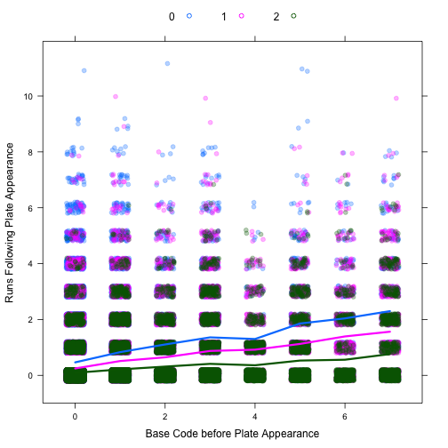

```r
xyplot(jitter(runsFuture) ~ jitter(startCode), groups = startOuts, data = ds.complete,
    alpha = 0.3, pch = 19, auto.key = list(columns = 3), xlab = "Base Code before Plate Appearance",
    ylab = "Runs Following Plate Appearance")
palette = trellis.par.get("superpose.symbol")$col
ladd(panel.lines(row.names(rem), rem[, 1], col = palette[1], lwd = 3))
ladd(panel.lines(row.names(rem), rem[, 2], col = palette[2], lwd = 3))
ladd(panel.lines(row.names(rem), rem[, 3], col = palette[3], lwd = 3))
```

We note that in general, each higher \( baseCode \) is associated with a larger number of expected \( futureRuns \), holding the number of \( outs \) constant. We can see this more clearly by looking simply at the model estimates.

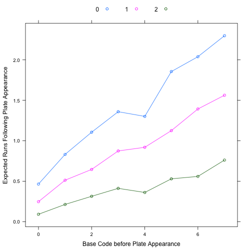

```r
xyplot(runs ~ startCode, groups = startOuts, data = states, type = c("p", "l"),
    auto.key = list(columns = 3), xlab = "Base Code before Plate Appearance",
    ylab = "Expected Runs Following Plate Appearance")
```

It is also instructive to examine the distribution of runs scored **on** (not \( futureRuns \), but rather \( runsOnPlay \)) a particular plate appearance.

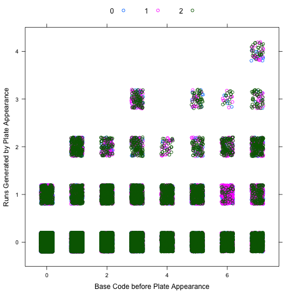

```r
xyplot(jitter(runsOnPlay) ~ jitter(startCode), groups = startOuts, data = ds.complete,
    auto.key = list(columns = 3), xlab = "Base Code before Plate Appearance",
    ylab = "Runs Generated by Plate Appearance")
```

#### Modeling Offense

We employ the notion of **conservation of runs**. That is, every run gained by the offense is a run lost by the defense. Thus, our first task is to determine, for each play, how many *expected* runs were gained by the offensive team. The defensive team must have lost that same number of *expected* runs. Let \( r_i \) be actual number of runs scored on the \( i^{th} \) play, and \( \rho(b,o) \) be the true expected value of the state \( (b,o) \). Then we define \[ \delta_i = \rho(b_{i+1},o_{i+1}) - \rho(b_i,o_i) + r_{i} \] to be the true number of expected runs gained on the \( i^{th} \) play. We stress that this quantity is unknown, since we can only estimate the true expected value associated with each \( (base, out) \) state.

For example, consider the half inning we visited previously.

```r
subset(gd$ds, inning == 1 & half == "bottom", select = c("runsFuture", "runsOnPlay",
    "startCode", "startOuts", "description"))
```

```
##   runsFuture runsOnPlay startCode startOuts
## 1          2          0         0         0
## 2          2          0         0         1
## 3          2          1         1         1
## 4          1          1         4         1
## 5          0          0         1         1
## 6          0          0         1         2
##                                                                                                                                                                            description
## 1                                                                                                                            Ruben Tejada flies out to center fielder Michael Bourn.
## 2                                                                                                                Mike Baxter singles on a line drive to right fielder Jason Heyward.
## 3 David Wright doubles (34) on a line drive to right fielder Jason Heyward.   Mike Baxter scores.  David Wright advances to 3rd, on a throwing error by right fielder Jason Heyward.
## 4                                                                                           Ike Davis singles on a line drive to right fielder Jason Heyward.   David Wright scores.
## 5                                                                                                                              Daniel Murphy lines out to left fielder Martin Prado.
## 6                                                                                                                                       Jordany Valdespin strikes out on a foul tip.
```

The inning began in the state \( (0,0) \). Our estimate \( \hat{\rho}(0,0) \) of the expected value (in runs) of that state is:

```r
fit.rem = getRunEx(ds)
fit.rem(baseCode = 0, outs = 0)
```

```
## [1] 0.4645
```

```r
# Note this is equivalent to rem[1,1]
```

On the first play of the inning, Ruben Tejada flied out. This moved the inning into the state \( (0,1) \), since there were still no runners on base, but now there was one out. The value of this state is

```r
fit.rem(0, 1)
```

```
## [1] 0.2467
```

The difference between these two states is \( \hat{\delta}_i \):

```r
fit.rem(0, 1) - fit.rem(0, 0)
```

```
## [1] -0.2178
```

In modeling this play, our goal is to apportion the value of \( \hat{\delta}_i \) to each of the offensive players. In this case, Tejada was the only offensive player involved, so he gets the full amount. Moreover, \( -\hat{\delta}_i \) must also be attributed to the defense. In this case, some of that credit will go to the pitcher, and some will go to the centerfielder. The details of this apportionment scheme will be revealed later.

The second batter, Mike Baxter, singled. This moved the inning from \( (0,1) \) to \( (1, 1) \). Accordingly, Baxter would receive:

```r
fit.rem(1, 1) - fit.rem(0, 1)
```

```
## [1] 0.2653
```

So far, so good. The next play is particularly complicated. David Wright doubles homes Baxter, and then advances to third on a throwing error by the rightfielder. Let's assume for a moment that the error didn't happen, and that Wright end the play on second base. In this case, the ending state is \( (2,1) \), but in addition, one run scored. Thus, the change in expected runs is:

```r
fit.rem(2, 1) - fit.rem(1, 1) + 1
```

```
## [1] 1.133
```

Clearly, much of the credit here should go to Wright, for hitting the double. But what about Baxter, who scored from first on a double? Our plan is to assume “ghostrunner” rules, wherein the number of bases advanced by each baserunner is determined by the type of hit. Since Wright hit a double, Baxter should have advanced two bases, leaving the inning in the state \( (6,1) \). The additional base that he advanced (from third to home) should then be given to Baxter. Thus, as a batter, Wright accrues:

```r
fit.rem(6, 1) - fit.rem(1, 1)
```

```
## [1] 0.8807
```

While Baxter accrues the remainder:

```r
fit.rem(2, 1) - fit.rem(6, 1) + 1
```

```
## [1] 0.2526
```

But now let's revisit what actually happened. Heyward's error allowed Wright to move to third. Thus, the state before the error occurred was \( (2,1) \) and it led to \( (4,1) \). The difference

```r
fit.rem(4, 1) - fit.rem(2, 1)
```

```
## [1] 0.2735
```

goes to Heyward as a rightfielder, and Wright as a baserunner.

Here is the function that will the “ghostrunner” state:

```r
ghostrunnerExR = function(startCode, startOuts, event) {
    if (event == "Home Run") {
        endCode = (startCode * 2^4)%%8
        outs = 0
        runs = sum(as.numeric(intToBits(startCode))) + 1
    } else if (event == "Triple") {
        endCode = (startCode * 2^3 + 4)%%8
        outs = 0
        runs = sum(as.numeric(intToBits(startCode)))
    } else if (event == "Double") {
        endCode = (startCode * 2^2 + 2)%%8
        outs = 0
        if (startCode >= 6) {
            runs = 2
        } else if (startCode >= 2) {
            runs = 1
        } else {
            runs = 0
        }
    } else if (event == "Single") {
        endCode = (startCode * 2^1 + 1)%%8
        outs = 0
        if (startCode >= 4) {
            runs = 1
        } else {
            runs = 0
        }
    } else if (event %in% c("Walk", "Intentional Walk", "Hit By Pitch")) {
        endCode = (startCode + 1)%%8
        outs = 0
        if (startCode == 7) {
            runs = 1
        } else {
            runs = 0
        }
    } else if (event %in% c("Grounded Into DP")) {
        endCode = startCode
        outs = 2
        if (startCode >= 4) {
            runs = 1
        } else {
            runs = 0
        }
    } else {
        endCode = startCode
        outs = 1
        runs = 0
    }
    endOuts = startOuts + outs
    if (endOuts == 3) {
        endExR = 0
    } else {
        endExR = fit.rem(endCode, endOuts)
    }
    return(endExR - fit.rem(startCode, startOuts) + runs)
}
```

So what does this look like? First, let's assign the beginning and ending state to each play.

```r
ds = transform(ds, startExR = fit.rem(startCode, startOuts))
ds = transform(ds, endExR = fit.rem(endCode, endOuts))
ds = transform(ds, delta = endExR - startExR + runsOnPlay)
```

Let's build a model based on the location of the hit

```r
# mod.bat = lm(delta ~ poly(our.x, 2) + poly(our.y, 2) + event, data=ds)
```

```r
# ds$delta.bat = mapply(ghostrunnerExR, ds$startCode, ds$startOuts,
# ds$event)
```

One of the nice features of this type of model is that in \( n \) completed innings, the number of expected runs generated should be exactly equal to the number of runs scored.

\[ \sum_{j \in innings} \sum_{i \in plays} \delta_{i}^j = \sum_{j \in innings} \sum_{i \in plays} \rho^j(b_{i+1}, o_{i+1}) - \rho^j(b_{i}, o_{i}) + r_{i}^j \] \[ = \sum_{j \in innings} \rho (0, 3) - \rho (0,0) + \sum_{i \in plays} r_i^j = - n \cdot \rho(0,0) + \sum_{j \in innings} \sum_{i \in plays} r_i^j \] This leads us to the estimate that \[ \hat{\rho}(0,0) = \frac{1}{n} \sum_{j \in innings} \sum_{i \in plays} r_i^j \]

If runs are conserved, then the sum of all of the \( \delta_i \)'s should be zero.

```r
ds.complete = subset(ds, outsInInning == 3)
sum(ds.complete$delta)
```

```
## [1] 16.06
```

Moreover, the total number of runs scored should match the product of the number of completed innings times \( \hat{\rho}(0,0) \).

```r
sum(ds.complete$runsOnPlay)
```

```
## [1] 11783
```

```r
N * fit.rem(0, 0)
```

```
## [1] 11767
```

Note that the runs are not equally distributed across innings.

```r
require(plyr)
ddply(ds, ~inning, summarise, N = length(inning), G = length(unique(gameId)),
    D = sum(delta, na.rm = TRUE))
```

```
##    inning     N    G          D
## 1       1 12096 1414  140.36844
## 2       2 11955 1414  -16.63156
## 3       3 11893 1414    9.36844
## 4       4 12042 1414  103.36844
## 5       5 12060 1414  111.36844
## 6       6 12081 1414  117.83295
## 7       7 12021 1412    8.69098
## 8       8 11850 1410 -109.91549
## 9       9  8934 1410 -180.96177
## 10     10  1267  150   23.95861
## 11     11   580   70   -7.78690
## 12     12   316   39  -16.93594
## 13     13   256   31   -4.45114
## 14     14   182   19   13.68642
## 15     15    91   10   -3.19916
## 16     16    62    8   -3.18540
## 17     17    35    5   -3.55407
## 18     18    31    4   -1.37831
## 19     19    14    2    0.23299
## 20     20     8    1    0.07098
```

#### Estimating Batting WAR

We're now in a position where we can compute the batting component of WAR.

```r
mod.bat = lm(delta ~ batterPos + stadium + (stand == throws), data = ds)
summary(mod.bat)
```

```
##
## Call:
## lm(formula = delta ~ batterPos + stadium + (stand == throws),
##     data = ds)
##
## Residuals:
##    Min     1Q Median     3Q    Max
## -1.908 -0.238 -0.159  0.239  3.369
##
## Coefficients:
##                                       Estimate Std. Error t value Pr(>|t|)
## (Intercept)                           0.041416   0.008787    4.71  2.4e-06
## batterPos2B                          -0.029423   0.006135   -4.80  1.6e-06
## batterPos3B                          -0.020435   0.006158   -3.32   0.0009
## batterPosC                           -0.029350   0.006221   -4.72  2.4e-06
## batterPosCF                          -0.024430   0.006093   -4.01  6.1e-05
## batterPosDH                          -0.016226   0.007672   -2.11   0.0344
## batterPosLF                          -0.016901   0.006100   -2.77   0.0056
## batterPosP                           -0.160582   0.009560  -16.80  < 2e-16
## batterPosPH                          -0.051252   0.009783   -5.24  1.6e-07
## batterPosRF                          -0.009238   0.006114   -1.51   0.1308
## batterPosSS                          -0.041356   0.006165   -6.71  2.0e-11
## batterPosUN                          -0.124403   0.101274   -1.23   0.2193
## stadiumGreat American Ball Park      -0.005262   0.011088   -0.47   0.6351
## stadiumYankee Stadium                -0.018244   0.010906   -1.67   0.0944
## stadiumPNC Park                      -0.024643   0.010944   -2.25   0.0243
## stadiumMiller Park                    0.007449   0.011006    0.68   0.4985
## stadiumTarget Field                   0.001224   0.011237    0.11   0.9133
## stadiumU.S. Cellular Field           -0.015517   0.011629   -1.33   0.1821
## stadiumNationals Park                -0.006205   0.011283   -0.55   0.5824
## stadiumTurner Field                  -0.007677   0.011226   -0.68   0.4941
## stadiumCiti Field                    -0.012734   0.011166   -1.14   0.2542
## stadiumO.co Coliseum                 -0.022328   0.011123   -2.01   0.0447
## stadiumDodger Stadium                -0.013137   0.010984   -1.20   0.2317
## stadiumChase Field                   -0.009578   0.011103   -0.86   0.3883
## stadiumTropicana Field               -0.010521   0.010732   -0.98   0.3269
## stadiumRogers Centre                  0.006717   0.011039    0.61   0.5429
## stadiumRangers Ballpark in Arlington -0.008724   0.011135   -0.78   0.4333
## stadiumCitizens Bank Park             0.002504   0.011091    0.23   0.8214
## stadiumOriole Park at Camden Yards    0.000922   0.010959    0.08   0.9330
```

[output cut: 47 more lines]

```
## stadiumFenway Park
## stadiumBusch Stadium
## stadiumSafeco Field
## stadiumWrigley Field
## stadiumKauffman Stadium
## stadiumProgressive Field
## stadiumPetco Park
## stadiumAngel Stadium of Anaheim
## stand == throwsTRUE                  ***
## ---
## Signif. codes:  0 '***' 0.001 '**' 0.01 '*' 0.05 '.' 0.1 ' ' 1
##
## Residual standard error: 0.475 on 107732 degrees of freedom
## Multiple R-squared:  0.00409,    Adjusted R-squared:  0.00371
## F-statistic: 10.8 on 41 and 107732 DF,  p-value: <2e-16
```

```r
ds = transform(ds, delta.bat = mod.bat$residuals)
war.bat = ddply(ds, ~batterId, summarise, Name = max(as.character(batterName)),
    PA = length(batterId), G = length(unique(gameId)), HR = sum(event == "Home Run"),
    RAA = sum(delta, na.rm = TRUE), RAA.bat = sum(delta.bat, na.rm = TRUE))
```

Who are the batting WAR leaders?

```r
war.bat[order(war.bat$RAA.bat, decreasing = TRUE), ]
```

```
##     batterId           Name  PA  G HR        RAA    RAA.bat
## 93    408234     Cabrera, M 429 93 30  57.162180  53.889919
## 271   448801       Davis, C 393 95 37  58.773029  46.082691
## 734   545361          Trout 426 92 15  40.865336  39.328307
## 621   518626      Donaldson 391 93 16  35.288231  37.977449
## 140   429664           Cano 411 95 21  34.020719  36.408713
## 587   502671    Goldschmidt 408 94 21  40.347388  31.988727
## 768   572761   Carpenter, M 410 89  9  31.563094  29.844904
## 545   501800          Craig 381 90 10  36.335803  29.614913
## 10    120074       Ortiz, D 331 77 19  34.364569  28.494926
## 377   457763          Posey 367 89 13  26.214427  27.966683
## 136   425877      Molina, Y 350 87  7  25.127740  27.650597
## 127   425783           Choo 435 92 13  29.543962  27.236163
## 316   453064     Tulowitzki 265 64 16  25.011365  26.845714
## 704   543401         Kipnis 376 84 13  26.749412  26.717013
```

[output cut: 781 more lines]

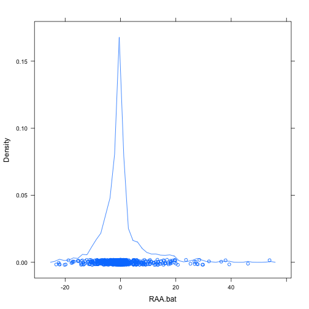

```r
densityplot(~RAA.bat, data = war.bat)
```

This makes a lot of sense.

```r
dw = subset(ds, batterId == 431151)
dw[order(dw$delta, decreasing = TRUE), c("event", "startCode", "endCode", "startOuts",
    "endOuts", "runsOnPlay", "startExR", "endExR", "delta", "delta.bat")]
```

```
##                      event startCode endCode startOuts endOuts runsOnPlay
## 211317              Double         7       6         1       1          2
## 7702              Home Run         1       0         1       1          2
## 27875             Home Run         1       0         1       1          2
## 34453             Home Run         1       0         0       0          2
## 3330                Double         1       4         1       1          1
## 44598               Double         2       4         0       0          1
## 10156               Double         6       2         0       0          2
## 71153               Triple         2       4         2       2          1
## 441322              Single         1       5         0       0          0
## 23148               Single         3       3         0       0          1
## 46194             Home Run         0       0         1       1          1
## 8360                Single         1       1         1       1          1
## 21352               Single         5       5         2       2          1
## 40344               Double         2       2         2       2          1
```

[output cut: 787 more lines]

#### Estimating Baserunning WAR

Now, we need to partition \( \delta \) among the (at most) four offensive players. We have already attributed the first (and usually largest) piece to the batter. For this iteration we'll simply split up the remainder equally among the baserunners.

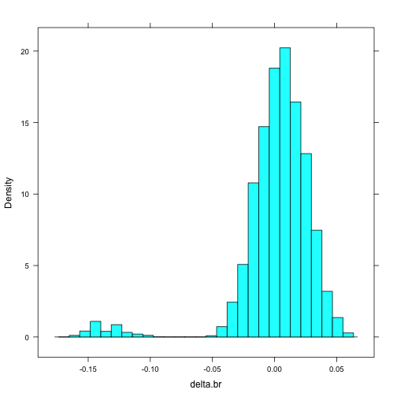

```r
ds = transform(ds, delta.br = delta - delta.bat)
xhistogram(~delta.br, data = ds)
```

```r
ds$delta.br1 = with(ds, ifelse(!is.na(start1B), delta.br/(1 * (!is.na(c("start1B",
    "start2B", "start3B")))) %*% c(1, 1, 1), NA))
ds$delta.br2 = with(ds, ifelse(!is.na(start2B), delta.br/(1 * (!is.na(c("start1B",
    "start2B", "start3B")))) %*% c(1, 1, 1), NA))
ds$delta.br3 = with(ds, ifelse(!is.na(start3B), delta.br/(1 * (!is.na(c("start1B",
    "start2B", "start3B")))) %*% c(1, 1, 1), NA))
```

Now compute for individual players

```r
war.br1 = ddply(ds, ~start1B, summarise, RAA.br1 = sum(delta.br1, na.rm = TRUE))
war.br1[order(war.br1$RAA.br1, decreasing = TRUE), ]
```

```
##     start1B    RAA.br1
## 81   408234  2.080e+00
## 268  453056  1.266e+00
## 297  456030  1.165e+00
## 507  516770  1.146e+00
## 100  425545  1.075e+00
## 121  425902  1.069e+00
## 154  430945  1.033e+00
## 147  430832  1.004e+00
## 79   408045  9.751e-01
## 9    120074  9.306e-01
## 66   405395  8.714e-01
## 644  572761  8.403e-01
## 22   150212  8.392e-01
## 618  545361  8.390e-01
```

[output cut: 651 more lines]

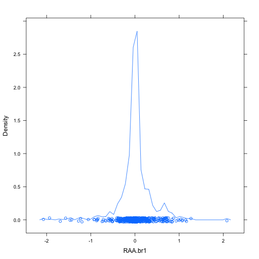

```r
densityplot(~RAA.br1, data = war.br1)
```

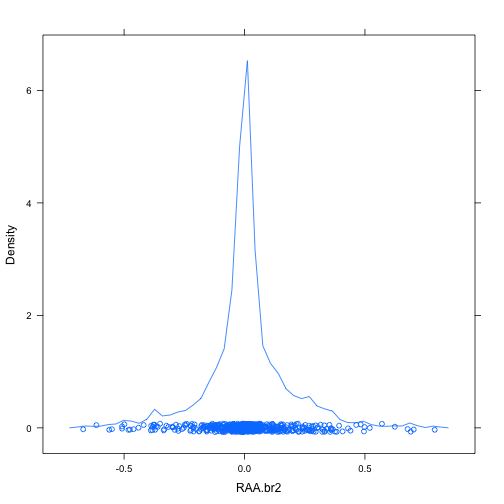

```r
war.br2 = ddply(ds, ~start2B, summarise, RAA.br2 = sum(delta.br2, na.rm = TRUE))
densityplot(~RAA.br2, data = war.br2)
```

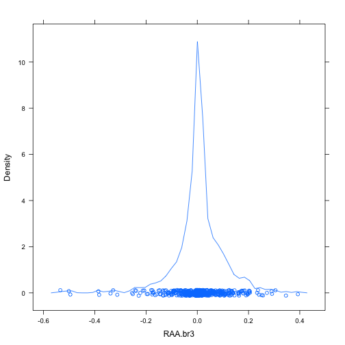

```r
war.br3 = ddply(ds, ~start3B, summarise, RAA.br3 = sum(delta.br3, na.rm = TRUE))
densityplot(~RAA.br3, data = war.br3)
```

Combine the offensive RAA estimates

```r
players = merge(x = war.bat, y = war.br1, by.x = "batterId", by.y = "start1B",
    all = TRUE)
players = merge(x = players, y = war.br2, by.x = "batterId", by.y = "start2B",
    all = TRUE)
players = merge(x = players, y = war.br3, by.x = "batterId", by.y = "start3B",
    all = TRUE)
players[is.na(players)] = 0
players = transform(players, RAA.br = RAA.br1 + RAA.br2 + RAA.br3)
players = transform(players, RAA = RAA.bat + RAA.br)
players[order(players$RAA, decreasing = TRUE), ]
```

```
##     batterId           Name  PA  G HR        RAA    RAA.bat    RAA.br1
## 93    408234     Cabrera, M 429 93 30  56.849714  53.889919  2.080e+00
## 271   448801       Davis, C 393 95 37  46.390331  46.082691  1.182e-01
## 734   545361          Trout 426 92 15  41.029662  39.328307  8.390e-01
## 621   518626      Donaldson 391 93 16  38.219552  37.977449  3.120e-01
## 140   429664           Cano 411 95 21  37.152996  36.408713  4.730e-01
## 587   502671    Goldschmidt 408 94 21  32.508592  31.988727  3.153e-01
## 768   572761   Carpenter, M 410 89  9  31.089540  29.844904  8.403e-01
## 10    120074       Ortiz, D 331 77 19  30.006043  28.494926  9.306e-01
## 545   501800          Craig 381 90 10  29.909680  29.614913  1.405e-01
## 377   457763          Posey 367 89 13  28.895468  27.966683  5.610e-01
## 316   453064     Tulowitzki 265 64 16  28.121719  26.845714  7.363e-01
## 704   543401         Kipnis 376 84 13  28.114569  26.717013  7.219e-01
## 127   425783           Choo 435 92 13  27.656705  27.236163 -1.432e-01
## 136   425877      Molina, Y 350 87  7  27.582065  27.650597  4.646e-01
```

[output cut: 1579 more lines]

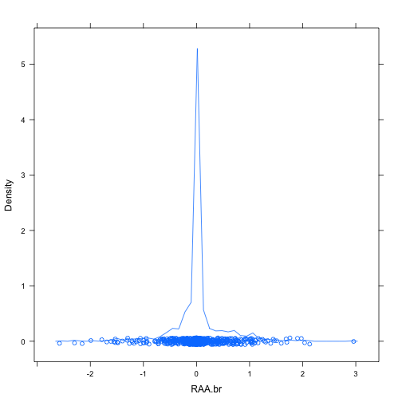

```r
densityplot(~RAA.br, data = players)
```

#### Estimating Fielding WAR

Who fielded each ball?

```r
ds = transform(ds, wasFielded = !is.na(fielderId))
ds$fielderPos = ifelse(is.na(ds$fielderId), "Hit", "Out")
ds$fielderPos = ifelse(!is.na(ds$fielderId) & ds$fielderId == ds$pitcherId,
    "P", ds$fielderPos)
ds$fielderPos = ifelse(!is.na(ds$fielderId) & ds$fielderId == ds$playerId.C,
    "C", ds$fielderPos)
ds$fielderPos = ifelse(!is.na(ds$fielderId) & ds$fielderId == ds$playerId.1B,
    "1B", ds$fielderPos)
ds$fielderPos = ifelse(!is.na(ds$fielderId) & ds$fielderId == ds$playerId.2B,
    "2B", ds$fielderPos)
ds$fielderPos = ifelse(!is.na(ds$fielderId) & ds$fielderId == ds$playerId.3B,
    "3B", ds$fielderPos)
ds$fielderPos = ifelse(!is.na(ds$fielderId) & ds$fielderId == ds$playerId.SS,
    "SS", ds$fielderPos)
ds$fielderPos = ifelse(!is.na(ds$fielderId) & ds$fielderId == ds$playerId.LF,
    "LF", ds$fielderPos)
ds$fielderPos = ifelse(!is.na(ds$fielderId) & ds$fielderId == ds$playerId.CF,
    "CF", ds$fielderPos)
ds$fielderPos = ifelse(!is.na(ds$fielderId) & ds$fielderId == ds$playerId.RF,
    "RF", ds$fielderPos)
tally(~fielderPos, data = ds)
```

```
##
##     1B     2B     3B      C     CF    Hit     LF      P     RF     SS
##   5013   8613   6616    711   7082  57044   5201   2980   5689   8825
##  Total
## 107774
```

To build the fielding models we'll need to consider only those events in which the ball was put into play.

```r
ds.field = subset(ds, isBIP == TRUE)
```

Next, we'll build 9 separate models – each giving the probability of a fielder making a play.

```r
# form = 'poly(our.x, 2) + poly(our.y, 2)'
mod.P = glm((fielderPos == "P") ~ poly(our.x, 2) + poly(our.y, 2), data = ds.field,
    family = "binomial")
mod.C = glm((fielderPos == "C") ~ poly(our.x, 2) + poly(our.y, 2), data = ds.field,
    family = "binomial")
mod.1B = glm((fielderPos == "1B") ~ poly(our.x, 2) + poly(our.y, 2), data = ds.field,
    family = "binomial")
mod.2B = glm((fielderPos == "2B") ~ poly(our.x, 2) + poly(our.y, 2), data = ds.field,
    family = "binomial")
mod.3B = glm((fielderPos == "3B") ~ poly(our.x, 2) + poly(our.y, 2), data = ds.field,
    family = "binomial")
mod.SS = glm((fielderPos == "SS") ~ poly(our.x, 2) + poly(our.y, 2), data = ds.field,
    family = "binomial")
mod.LF = glm((fielderPos == "LF") ~ poly(our.x, 2) + poly(our.y, 2), data = ds.field,
    family = "binomial")
mod.CF = glm((fielderPos == "CF") ~ poly(our.x, 2) + poly(our.y, 2), data = ds.field,
    family = "binomial")
mod.RF = glm((fielderPos == "RF") ~ poly(our.x, 2) + poly(our.y, 2), data = ds.field,
    family = "binomial")
summary(mod.SS)
```

```
##
## Call:
## glm(formula = (fielderPos == "SS") ~ poly(our.x, 2) + poly(our.y,
##     2), family = "binomial", data = ds.field)
##
## Deviance Residuals:
##    Min      1Q  Median      3Q     Max
## -2.187  -0.058  -0.001   0.000   8.490
##
## Coefficients:
##                  Estimate Std. Error z value Pr(>|z|)
## (Intercept)       -16.203      0.216   -74.9   <2e-16 ***
## poly(our.x, 2)1 -1668.662     28.275   -59.0   <2e-16 ***
## poly(our.x, 2)2 -2521.920     47.857   -52.7   <2e-16 ***
## poly(our.y, 2)1 -2336.017     50.691   -46.1   <2e-16 ***
## poly(our.y, 2)2 -2200.955     37.834   -58.2   <2e-16 ***
## ---
## Signif. codes:  0 '***' 0.001 '**' 0.01 '*' 0.05 '.' 0.1 ' ' 1
##
## (Dispersion parameter for binomial family taken to be 1)
##
##     Null deviance: 45626  on 67666  degrees of freedom
## Residual deviance: 14894  on 67662  degrees of freedom
## AIC: 14904
##
## Number of Fisher Scoring iterations: 11
```

```r
fit.SS = makeFun(mod.SS)
# require(gridExtra) grid.arrange(p4, p6) print(p4, split=c(1,1,1,2))
# print(p6, split=c(1,2,1,2))
fit.P = makeFun(mod.P)
fit.C = makeFun(mod.C)
fit.1B = makeFun(mod.1B)
fit.2B = makeFun(mod.2B)
fit.3B = makeFun(mod.3B)
fit.LF = makeFun(mod.LF)
fit.CF = makeFun(mod.CF)
fit.RF = makeFun(mod.RF)

plotFun(fit.SS(x, y) ~ x + y, surface = TRUE, alpha = 1, x.lim = c(-300, 300),
    y.lim = c(0, 400))
```

```
## Error: no such symbol rs_createUUID
```

```r
plotFun(fit.2B(x, y) ~ x + y, surface = TRUE, alpha = 1, x.lim = c(-300, 300),
    y.lim = c(0, 400))
```

```
## Error: no such symbol rs_createUUID
```

```r
plotFun(fit.LF(x, y) ~ x + y, surface = TRUE, alpha = 1, x.lim = c(-300, 300),
    y.lim = c(0, 500))
```

```
## Error: no such symbol rs_createUUID
```

```r
plotFun(fit.CF(x, y) ~ x + y, surface = TRUE, alpha = 1, x.lim = c(-300, 300),
    y.lim = c(0, 500))
```

```
## Error: no such symbol rs_createUUID
```

```r
plotFun(fit.RF(x, y) ~ x + y, surface = TRUE, alpha = 1, x.lim = c(-300, 300),
    y.lim = c(0, 500))
```

```
## Error: no such symbol rs_createUUID
```

```r
plotFun(fit.1B(x, y) ~ x + y, surface = TRUE, alpha = 1, x.lim = c(-300, 300),
    y.lim = c(0, 400))
```

```
## Error: no such symbol rs_createUUID
```

```r
plotFun(fit.3B(x, y) ~ x + y, surface = TRUE, alpha = 1, x.lim = c(-300, 300),
    y.lim = c(0, 400))
```

```
## Error: no such symbol rs_createUUID
```

```r
plotFun(fit.P(x, y) ~ x + y, surface = TRUE, alpha = 1, x.lim = c(-300, 300),
    y.lim = c(0, 400))
```

```
## Error: no such symbol rs_createUUID
```

```r
plotFun(fit.C(x, y) ~ x + y, surface = TRUE, alpha = 1, x.lim = c(-300, 300),
    y.lim = c(0, 400))
```

```
## Error: no such symbol rs_createUUID
```

What is the probability of **any** fielder making a play?

```r
fit.all = makeFun(fit.P(x, y) + fit.C(x, y) + fit.1B(x, y) + fit.2B(x, y) +
    fit.3B(x, y) + fit.SS(x, y) + fit.LF(x, y) + fit.CF(x, y) + fit.RF(x, y) ~
    x + y)
one = makeFun(1 ~ x + y)
fit.total = makeFun(min(one(x, y), fit.all(x, y)) ~ x + y)
plotFun(fit.total(x, y) ~ x + y, surface = TRUE, alpha = 1, x.lim = c(-300,
    300), y.lim = c(0, 500))
```

```
## Error: dims [product 1600] do not match the length of object [1]
```

Allocate the defensive responsibility.

```r
field.idx = which(ds$isBIP == TRUE)
ds[field.idx, "resp.P"] = mod.P$fitted
ds[field.idx, "resp.C"] = mod.C$fitted
ds[field.idx, "resp.1B"] = mod.1B$fitted
ds[field.idx, "resp.2B"] = mod.2B$fitted
ds[field.idx, "resp.3B"] = mod.3B$fitted
ds[field.idx, "resp.SS"] = mod.SS$fitted
ds[field.idx, "resp.LF"] = mod.LF$fitted
ds[field.idx, "resp.CF"] = mod.CF$fitted
ds[field.idx, "resp.RF"] = mod.RF$fitted
ds = transform(ds, resp.field = pmin(1, resp.P + resp.C + resp.1B + resp.2B +
    resp.3B + resp.SS + resp.LF + resp.CF + resp.RF))
ds$delta.field = with(ds, ifelse(wasFielded, delta * (1 - resp.field), delta *
    resp.field))
ds = transform(ds, delta.P = delta.field * (resp.P/resp.field))
ds = transform(ds, delta.C = delta.field * (resp.C/resp.field))
ds = transform(ds, delta.1B = delta.field * (resp.1B/resp.field))
ds = transform(ds, delta.2B = delta.field * (resp.2B/resp.field))
ds = transform(ds, delta.3B = delta.field * (resp.3B/resp.field))
ds = transform(ds, delta.SS = delta.field * (resp.SS/resp.field))
ds = transform(ds, delta.LF = delta.field * (resp.LF/resp.field))
ds = transform(ds, delta.CF = delta.field * (resp.CF/resp.field))
ds = transform(ds, delta.RF = delta.field * (resp.RF/resp.field))
ds$delta.pitch = with(ds, ifelse(is.na(delta.field), delta, delta - delta.field))
```

Fit one surface for all fielders.

```r
mod.all = glm(!is.na(fielderId) ~ poly(our.x, 12) + poly(our.y, 12) + our.x *
    our.y, data = ds.field, family = "binomial")
summary(mod.all)
```

```
##
## Call:
## glm(formula = !is.na(fielderId) ~ poly(our.x, 12) + poly(our.y,
##     12) + our.x * our.y, family = "binomial", data = ds.field)
##
## Deviance Residuals:
##    Min      1Q  Median      3Q     Max
## -3.199  -0.964   0.447   0.844   2.481
##
## Coefficients: (2 not defined because of singularities)
##                    Estimate Std. Error z value Pr(>|z|)
## (Intercept)        9.33e-01   1.14e-02   81.75  < 2e-16 ***
## poly(our.x, 12)1   1.15e+02   1.29e+01    8.94  < 2e-16 ***
## poly(our.x, 12)2  -7.24e+01   2.17e+01   -3.34  0.00083 ***
## poly(our.x, 12)3   8.14e+01   4.04e+01    2.01  0.04413 *
## poly(our.x, 12)4  -2.06e+02   6.89e+01   -2.98  0.00285 **
## poly(our.x, 12)5   1.95e+02   8.87e+01    2.20  0.02778 *
## poly(our.x, 12)6  -1.84e+02   8.34e+01   -2.21  0.02741 *
## poly(our.x, 12)7   7.79e+01   5.18e+01    1.50  0.13256
## poly(our.x, 12)8  -6.16e+01   3.27e+01   -1.89  0.05936 .
## poly(our.x, 12)9   4.54e+01   1.69e+01    2.69  0.00711 **
## poly(our.x, 12)10 -1.71e+01   1.19e+01   -1.44  0.15040
## poly(our.x, 12)11  2.36e+01   6.39e+00    3.68  0.00023 ***
## poly(our.x, 12)12 -3.01e+01   5.51e+00   -5.46  4.9e-08 ***
## poly(our.y, 12)1  -2.07e+02   8.91e+00  -23.28  < 2e-16 ***
## poly(our.y, 12)2   1.86e+02   2.30e+01    8.07  6.8e-16 ***
## poly(our.y, 12)3   1.17e+02   4.00e+01    2.92  0.00350 **
## poly(our.y, 12)4   1.13e+02   7.90e+01    1.43  0.15344
## poly(our.y, 12)5   1.40e+02   9.35e+01    1.50  0.13434
## poly(our.y, 12)6   2.99e+02   7.84e+01    3.82  0.00013 ***
## poly(our.y, 12)7   1.22e+02   4.34e+01    2.82  0.00487 **
## poly(our.y, 12)8  -3.28e+01   2.37e+01   -1.38  0.16726
## poly(our.y, 12)9   5.35e+01   1.38e+01    3.88  0.00010 ***
## poly(our.y, 12)10  3.73e+01   7.33e+00    5.08  3.7e-07 ***
## poly(our.y, 12)11 -1.50e+01   4.56e+00   -3.29  0.00101 **
## poly(our.y, 12)12  1.58e+01   4.01e+00    3.93  8.3e-05 ***
## our.x                    NA         NA      NA       NA
## our.y                    NA         NA      NA       NA
## our.x:our.y       -1.28e-05   1.56e-06   -8.22  < 2e-16 ***
## ---
## Signif. codes:  0 '***' 0.001 '**' 0.01 '*' 0.05 '.' 0.1 ' ' 1
##
## (Dispersion parameter for binomial family taken to be 1)
##
##     Null deviance: 86398  on 67666  degrees of freedom
## Residual deviance: 69581  on 67641  degrees of freedom
## AIC: 69633
##
## Number of Fisher Scoring iterations: 7
```

```r
fit.all = makeFun(mod.all)
plotFun(fit.all(x, y) ~ x + y, surface = TRUE, alpha = 1, x.lim = c(-300, 300),
    y.lim = c(0, 500))
```

```
## Error: no such symbol rs_createUUID
```

Who's made the most plays?

```r
lkup.b = ds[, c("batterId", "batterName")]
lkup.p = ds[, c("pitcherId", "pitcherName")]
names(lkup.p) = names(lkup.b)
lkup = unique(rbind(lkup.b, lkup.p))
```

Who are the best fielding pitchers?

```r
war.P = ddply(ds, ~pitcherId, summarise, RAA.P = sum(delta.P, na.rm = TRUE))
war.P[order(war.P$RAA.P, decreasing = FALSE), ]
```

```
##     pitcherId      RAA.P
## 30     279782 -8.471e-01
## 70     425794 -7.741e-01
## 35     285079 -7.164e-01
## 149    445590 -6.965e-01
## 548    547874 -6.404e-01
## 407    502239 -6.249e-01
## 37     346793 -5.936e-01
## 203    452718 -5.607e-01
## 462    519043 -5.249e-01
## 16     150302 -5.201e-01
## 48     407825 -5.046e-01
## 61     425386 -5.002e-01
## 81     429722 -4.894e-01
## 259    458550 -4.676e-01
```

[output cut: 579 more lines]

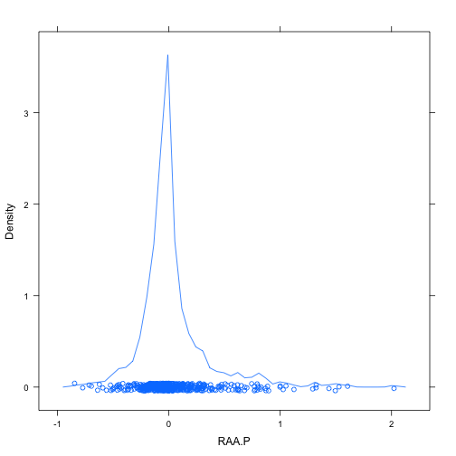

```r
densityplot(~RAA.P, data = war.P)
```

Who are the best fielding catchers?

```r
war.C = ddply(ds, ~playerId.C, summarise, RAA.C = sum(delta.C, na.rm = TRUE))
war.C[order(war.C$RAA.C, decreasing = FALSE), ]
```

```
##    playerId.C      RAA.C
## 54     460026 -3.421e-01
## 20     430591 -1.070e-01
## 66     500207 -9.378e-02
## 35     446653 -8.051e-02
## 39     452672 -7.400e-02
## 8      400018 -6.152e-02
## 48     456078 -5.581e-02
## 72     518960 -5.449e-02
## 49     456124 -4.747e-02
## 65     491696 -4.221e-02
## 13     424325 -3.347e-02
## 58     471083 -2.226e-02
## 4      150275 -1.794e-02
## 75     519222 -1.436e-02
```

[output cut: 75 more lines]

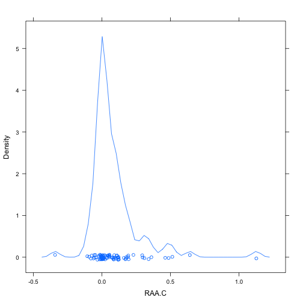

```r
densityplot(~RAA.C, data = war.C)
```

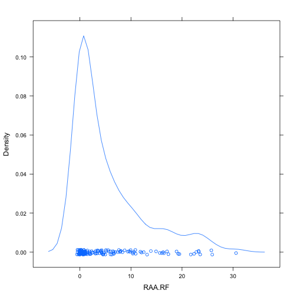

```r
war.1B = ddply(ds, ~playerId.1B, summarise, RAA.1B = sum(delta.1B, na.rm = TRUE))
war.2B = ddply(ds, ~playerId.2B, summarise, RAA.2B = sum(delta.2B, na.rm = TRUE))
war.3B = ddply(ds, ~playerId.3B, summarise, RAA.3B = sum(delta.3B, na.rm = TRUE))
war.SS = ddply(ds, ~playerId.SS, summarise, RAA.SS = sum(delta.SS, na.rm = TRUE))
war.LF = ddply(ds, ~playerId.LF, summarise, RAA.LF = sum(delta.LF, na.rm = TRUE))
war.CF = ddply(ds, ~playerId.CF, summarise, RAA.CF = sum(delta.CF, na.rm = TRUE))
war.RF = ddply(ds, ~playerId.RF, summarise, RAA.RF = sum(delta.RF, na.rm = TRUE))
densityplot(~RAA.RF, data = war.RF)
```

The distribution is not fair, because balls hit to the outfield have higher run consequence.

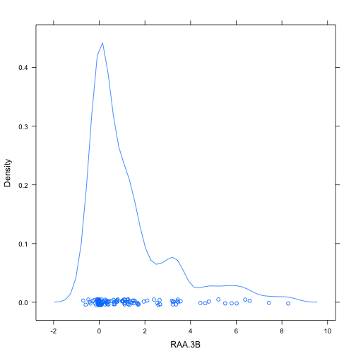

```r
densityplot(~RAA.3B, data = war.3B)
```

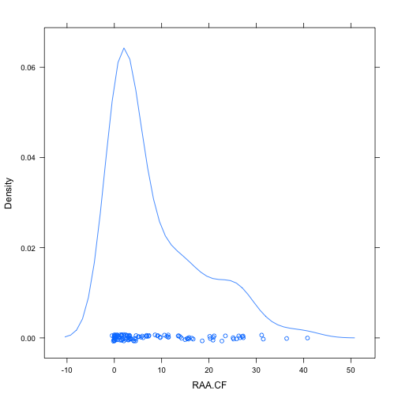

```r
densityplot(~RAA.CF, data = war.CF)
```

How is an individual player affected?

```r
dw = subset(ds, playerId.CF == 460576)
head(dw[order(dw$delta.CF, decreasing = TRUE), c("event", "startCode", "endCode",
    "startOuts", "endOuts", "runsOnPlay", "startExR", "endExR", "delta", "delta.pitch",
    "delta.field", "delta.CF", "description")], 100)
```

```
##              event startCode endCode startOuts endOuts runsOnPlay startExR
## 55328       Double         3       2         2       2          2   0.4114
## 611744      Single         7       3         2       2          2   0.7610
## 151192      Double         3       2         0       0          2   1.3591
## 27530       Double         3       6         0       0          1   1.3591
## 32214       Double         5       2         1       1          2   1.1251
## 9071        Triple         1       4         2       2          1   0.2126
## 2677        Single         7       3         2       2          2   0.7610
## 43749       Single         7       3         2       2          2   0.7610
## 50625       Single         3       3         2       2          1   0.4114
## 471077      Double         1       2         2       2          1   0.2126
## 46210       Single         7       5         2       2          2   0.7610
## 26641       Single         3       3         1       1          1   0.8738
## 13544  Field Error         1       6         0       0          0   0.8311
## 20889       Double         1       2         2       2          1   0.2126
```

[output cut: 288 more lines]

#### Estimating Pitching WAR

```r
war.pitch = ddply(ds, ~pitcherId, summarise, Name = max(as.character(pitcherName)),
    RAA.pitch = sum(delta.pitch))
war.pitch[order(war.pitch$RAA.pitch, decreasing = FALSE), ]
```

```
##     pitcherId           Name RAA.pitch
## 70     425794     Wainwright -39.78540
## 340    477132        Kershaw -38.19936
## 451    518774         Harvey -36.16589
## 108    433587   Hernandez, F -32.56973
## 481    519455     Zimmermann -30.59534
## 1      112526          Colon -30.02460
## 395    502046          Locke -29.64342
## 557    571578         Corbin -29.60550
## 60     424324        Lee, Cl -27.80787
## 549    547943            Ryu -27.79725
## 415    502706     Holland, D -27.00420
## 170    448306        Shields -25.68250
## 286    461829   Gonzalez, Gi -24.38953
## 220    453329       Buchholz -24.38430
```

[output cut: 579 more lines]

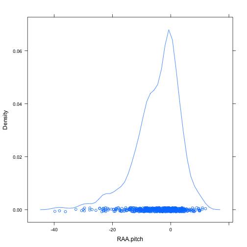

```r
densityplot(~RAA.pitch, data = war.pitch)
```

```r
players = merge(x = players, y = war.pitch, by.x = "batterId", by.y = "pitcherId",
    all = TRUE)
players$Name = with(players, ifelse(is.na(Name.x), Name.y, Name.x))
players = merge(x = players, y = war.P, by.x = "batterId", by.y = "pitcherId",
    all = TRUE)
players = merge(x = players, y = war.C, by.x = "batterId", by.y = "playerId.C",
    all = TRUE)
players = merge(x = players, y = war.1B, by.x = "batterId", by.y = "playerId.1B",
    all = TRUE)
players = merge(x = players, y = war.2B, by.x = "batterId", by.y = "playerId.2B",
    all = TRUE)
players = merge(x = players, y = war.3B, by.x = "batterId", by.y = "playerId.3B",
    all = TRUE)
players = merge(x = players, y = war.SS, by.x = "batterId", by.y = "playerId.SS",
    all = TRUE)
players = merge(x = players, y = war.LF, by.x = "batterId", by.y = "playerId.LF",
    all = TRUE)
players = merge(x = players, y = war.CF, by.x = "batterId", by.y = "playerId.CF",
    all = TRUE)
players = merge(x = players, y = war.RF, by.x = "batterId", by.y = "playerId.RF",
    all = TRUE)
players[is.na(players)] = 0
players = transform(players, RAA.field = RAA.P + RAA.C + RAA.1B + RAA.2B + RAA.3B +
    RAA.SS + RAA.LF + RAA.CF + RAA.RF)
players = transform(players, RAA = RAA.bat + RAA.br - RAA.pitch - RAA.field)
```

And now, the moment you've all been waiting for…

```r
head(players[order(players$RAA, decreasing = TRUE), c("Name", "RAA", "RAA.bat",
    "RAA.br", "RAA.field", "RAA.pitch")], 100)
```

```
##               Name   RAA  RAA.bat     RAA.br  RAA.field RAA.pitch
## 126     Cabrera, M 49.42 53.88992  2.9597951  7.4343115      0.00
## 369       Davis, C 45.68 46.08269  0.3076405  0.7075424      0.00
## 684        Kershaw 37.37 -1.01238  0.0955205 -0.0829789    -38.20
## 171     Wainwright 36.98 -3.60140  0.0215763 -0.7741273    -39.79
## 878      Donaldson 34.77 37.97745  0.2421031  3.4454810      0.00
## 184           Cano 33.90 36.40871  0.7442830  3.2566098      0.00
## 889         Harvey 32.98 -3.13774  0.0023908  0.0469561    -36.17
## 247   Hernandez, F 32.69  0.14350  0.0074545  0.0298265    -32.57
## 826    Goldschmidt 32.50 31.98873  0.5198652  0.0064534      0.00
## 1073        Corbin 31.10  1.56867  0.0262238  0.1040593    -29.61
## 942     Zimmermann 30.76  0.03799  0.0318934 -0.0931308    -30.60
## 14        Ortiz, D 30.01 28.49493  1.5111174 -0.0061019      0.00
## 666        Wood, T 28.90  5.76966  0.0652185 -0.2241005    -22.84
## 1061           Ryu 28.86  1.14815  0.0057005  0.0928254    -27.80
```

[output cut: 86 more lines]

```r
head(players[order(players$RAA, decreasing = FALSE), c("Name", "RAA", "RAA.bat",
    "RAA.br", "RAA.field", "RAA.pitch")], 100)
```

```
##                Name    RAA  RAA.bat    RAA.br RAA.field RAA.pitch
## 316             Jay -50.51  -8.3861 -1.296032   40.8298    0.0000
## 174        Upton, B -47.24 -18.8250 -1.395632   27.0157    0.0000
## 586      Murphy, Dv -44.29 -20.2185  0.311850   24.9595   -0.5760
## 680        Parmelee -41.34 -19.8127  0.134786   21.6635    0.0000
## 75         Hamilton -40.24 -17.3924  0.440525   23.2833    0.0000
## 997           Hicks -37.57 -11.0641  0.065237   26.5710    0.0000
## 1085        Pollock -37.04  -8.4403 -0.615629   27.9792    0.0000
## 582            Kemp -35.96  -9.0346  0.283492   27.2111    0.0000
## 980           Dirks -35.43 -17.7273  0.646276   18.3500    0.0000
## 924          Revere -34.65  -8.2347 -0.564693   25.8504    0.0000
## 732            Aoki -31.68  -5.5817 -0.189341   25.9114    0.0000
## 549        Young, E -31.45  -9.0404  0.684507   23.0950    0.0000
## 624        Parra, G -31.03  -2.3123 -0.240501   28.4804    0.0000
## 693       Barnes, B -30.37   0.5489  0.203868   31.1267    0.0000
```

[output cut: 86 more lines]

#### Final Output

We have our point estimates, but now let's put some variance estimates on those.

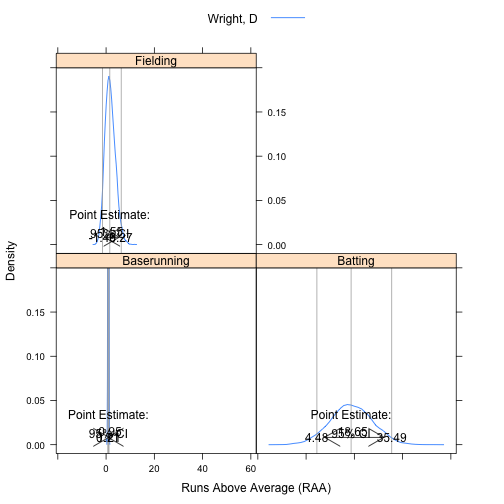

```r
warplot(431151, data = ds)
```

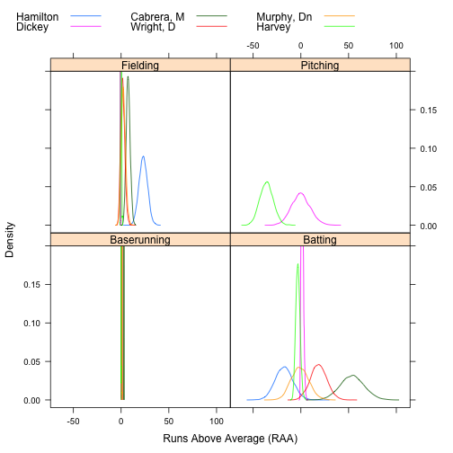

```r
warplot(c(431151, 502517, 408234, 285078, 518774, 285079), data = ds)
```